# : how differentiated are two populations?

Then let's have a look at the results:

```
# some hartebeest samples were also originally included in this data set, but now we can just remove those from
# the output
grep -ve Hartebeest plink2.fst.summary > tmp
mv tmp plink2.fst.summary

# print the results
column -t plink2.fst.summary
```

```
#POP1     POP2       HUDSON_FST
Amboseli  Black      0.531708
Amboseli  Ethosha    0.224743
Amboseli  Luangwa    0.301884
Amboseli  Monduli    0.110156
Amboseli  Nairobi    0.000902228
Amboseli  Selous     0.295483
Amboseli  Serengeti  0.170069
Black     Ethosha    0.443276
Black     Luangwa    0.536717
Black     Monduli    0.481127
Black     Nairobi    0.526759
Black     Selous     0.539495
Black     Serengeti  0.490266
Ethosha   Luangwa    0.193734
Ethosha   Monduli    0.147586
Ethosha   Nairobi    0.217494
Ethosha   Selous     0.19825
Ethosha   Serengeti  0.164245
Luangwa   Monduli    0.220976
Luangwa   Nairobi    0.293731
Luangwa   Selous     0.195965
Luangwa   Serengeti  0.24107
Monduli   Nairobi    0.101553
Monduli   Selous     0.21675
Monduli   Serengeti  0.0246107
Nairobi   Selous     0.287543
Nairobi   Serengeti  0.161879
Selous    Serengeti  0.240375
```

**Questions**

**- Which populations are most genetically differentiated? Which are most similar?**

**- Can you indentify a pattern in the Fst values between black wildebeest and each of the blue wildebeest populations? Try to see if you can explain this pattern.**

Are each of these values large or small? This is quite difficult to answer without context, as it will depend on the type of data you are analyzing, the amount of data and the scope of your study. To provide context, one often looks at a matrix of values, which can be visualized using a heatmap. To do this we first need to transform the above data frame into a matrix, and then generate a heatmap using the heatmap.2-function.

```
options(repr.matrix.max.cols=10, repr.matrix.max.rows=10)
options(repr.plot.width=16, repr.plot.height=16)
library(gplots)

# read the data into R
fst <- read.table("./plink2.fst.summary")
names(fst) <- c("pop1", "pop2", "est")
fst <- fst[fst$pop1 != "Hartebeest" & fst$pop2 != "Hartebeest",]
```

**Question**

- The pairwise table is turned into a matrix here. Which pair has the highest Fst, and does the black wildebeest outgroup behave as you expected?

Here we transform the table from above into a pairwise matrix that contains the exact same information, just in a different format:

```
mat <- matrix(NA, 8, 8)
mat[lower.tri(mat)] <- fst$est
mat <- t(mat)
mat[lower.tri(mat)] <- fst$est
colnames(mat) <- c( "Amboseli", fst[1:7,2])
rownames(mat) <- c( "Amboseli", fst[1:7,2])
mat
```

A matrix: 8 × 8 of type dbl

|  | Amboseli | Black | Ethosha | Luangwa | Monduli | Nairobi | Selous | Serengeti |
| --- | --- | --- | --- | --- | --- | --- | --- | --- |
| Amboseli | NA | 0.531708 | 0.224743 | 0.301884 | 0.1101560 | 0.000902228 | 0.295483 | 0.1700690 |
| Black | 0.531708000 | NA | 0.443276 | 0.536717 | 0.4811270 | 0.526759000 | 0.539495 | 0.4902660 |
| Ethosha | 0.224743000 | 0.443276 | NA | 0.193734 | 0.1475860 | 0.217494000 | 0.198250 | 0.1642450 |
| Luangwa | 0.301884000 | 0.536717 | 0.193734 | NA | 0.2209760 | 0.293731000 | 0.195965 | 0.2410700 |
| Monduli | 0.110156000 | 0.481127 | 0.147586 | 0.220976 | NA | 0.101553000 | 0.216750 | 0.0246107 |
| Nairobi | 0.000902228 | 0.526759 | 0.217494 | 0.293731 | 0.1015530 | NA | 0.287543 | 0.1618790 |
| Selous | 0.295483000 | 0.539495 | 0.198250 | 0.195965 | 0.2167500 | 0.287543000 | NA | 0.2403750 |
| Serengeti | 0.170069000 | 0.490266 | 0.164245 | 0.241070 | 0.0246107 | 0.161879000 | 0.240375 | NA |

**Question**

```
heatmap.2(mat, symm=T, trace='n', cexRow=1.5, cexCol=1.5, margins = c(12, 12))
```

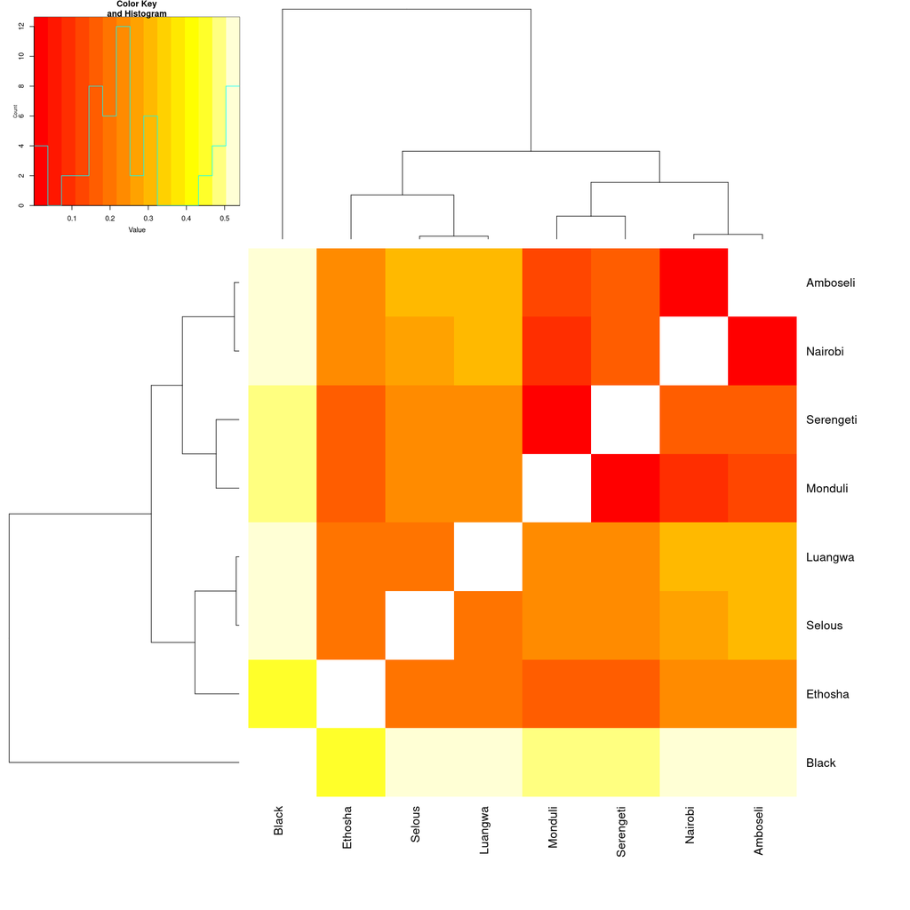

**- Look at the clustering tree produced by this method. Do the different groups relate to each other as we would expect?**

**- We can see some discrete levels of values in the color key and in the histogram in the inset plot. What do these correspond to?**

An important note here is that the tree/dendrogram used to order the groups here simply comes from clustering based on the values and will not neccesarily reflect the true evolutionary history of the groups.

```
# run to start quiz
from jupyterquiz import display_quiz
display_quiz('https://raw.githubusercontent.com/popgenDK/courses/main/current_exercises/relatedness_diversity/quiz/quiz_wildebeest_fst.json')
```

# Extra/optional - Reindeer SAF-based - Using genotype Likelihood

We now estimate genotype-likelihood-based differentiation for **Qassit**, **Neria**, and **Ameralik**. The ANGSD SAF files are supplied in `reindeer_saf`; do not regenerate them.

Each population needs a matching `.saf.idx`, `.saf.gz`, and `.saf.pos.gz` triplet. These SAFs must be full-dimensional (not generated with `ANGSD -fold 1`) and must use the same reference and compatible filters.

`winsfs` estimates the pairwise 2D-SFS. We then remove its `#SHAPE` header and use ANGSD's `realSFS fst` functions for global and windowed .

```
# the working folder was created and entered in the setup cell
SAF_DIR=reindeer_saf
pops=(Qassit Neria Ameralik)
extensions=(saf.idx saf.gz saf.pos.gz)
missing=0

for pop in "${pops[@]}"; do
  for extension in "${extensions[@]}"; do
    file="$SAF_DIR/$pop.$extension"
    if [[ ! -s "$file" ]]; then
      echo "MISSING: $file" >&2
      missing=1
    fi
  done
done

if (( missing )); then
  echo "Add all nine supplied SAF components to $SAF_DIR before continuing." >&2
  exit 1
fi

echo "All supplied SAF components were found."
ls -lh "$SAF_DIR"/{Qassit,Neria,Ameralik}.saf.{idx,gz,pos.gz}
```

```
All supplied SAF components were found.
lrwxrwxrwx 1 albrecht admin 58 Sep 16 19:59 reindeer_saf/Ameralik.saf.gz -> /course/data/current_data/fst/reindeer_saf/Ameralik.saf.gz
lrwxrwxrwx 1 albrecht admin 59 Sep 16 19:59 reindeer_saf/Ameralik.saf.idx -> /course/data/current_data/fst/reindeer_saf/Ameralik.saf.idx
lrwxrwxrwx 1 albrecht admin 62 Sep 16 19:59 reindeer_saf/Ameralik.saf.pos.gz -> /course/data/current_data/fst/reindeer_saf/Ameralik.saf.pos.gz
lrwxrwxrwx 1 albrecht admin 55 Sep 16 19:59 reindeer_saf/Neria.saf.gz -> /course/data/current_data/fst/reindeer_saf/Neria.saf.gz
lrwxrwxrwx 1 albrecht admin 56 Sep 16 19:59 reindeer_saf/Neria.saf.idx -> /course/data/current_data/fst/reindeer_saf/Neria.saf.idx
lrwxrwxrwx 1 albrecht admin 59 Sep 16 19:59 reindeer_saf/Neria.saf.pos.gz -> /course/data/current_data/fst/reindeer_saf/Neria.saf.pos.gz
lrwxrwxrwx 1 albrecht admin 56 Sep 16 19:59 reindeer_saf/Qassit.saf.gz -> /course/data/current_data/fst/reindeer_saf/Qassit.saf.gz
lrwxrwxrwx 1 albrecht admin 57 Sep 16 19:59 reindeer_saf/Qassit.saf.idx -> /course/data/current_data/fst/reindeer_saf/Qassit.saf.idx
lrwxrwxrwx 1 albrecht admin 60 Sep 16 19:59 reindeer_saf/Qassit.saf.pos.gz -> /course/data/current_data/fst/reindeer_saf/Qassit.saf.pos.gz
```

**Question**

- These are SAF files rather than genotypes. What does a site allele frequency likelihood store that a called genotype throws away?

```
echo "This command was used to generate the precomputed files:"
echo "SAF_DIR=reindeer_saf
OUT=.
THREADS=40

pairs=("Qassit Neria" "Qassit Ameralik" "Neria Ameralik")

for pair in "${pairs[@]}"; do
  read -r pop1 pop2 <<< "$pair"
  prefix="$OUT/${pop1}_${pop2}"
  echo "Estimating $pop1 versus $pop2"

  winsfs --threads "$THREADS" --seed 2026 \
    "$SAF_DIR/$pop1.saf.idx" "$SAF_DIR/$pop2.saf.idx" \
    > "$prefix.winsfs"

  # winsfs writes a #SHAPE header; realSFS fst expects only numeric SFS values.
  tail -n 1 "$prefix.winsfs" > "$prefix.2dsfs"

  realSFS fst index \
    "$SAF_DIR/$pop1.saf.idx" "$SAF_DIR/$pop2.saf.idx" \
    -sfs "$prefix.2dsfs" -fstout "$prefix"

  realSFS fst stats "$prefix.fst.idx" > "$prefix.global_fst.txt"
  realSFS fst stats2 "$prefix.fst.idx" -win 100000 -step 50000 \
    > "$prefix.100kb_fst.tsv"
done"

echo
echo "Estimating Qassit versus Neria
Estimating Qassit versus Ameralik
Estimating Neria versus Ameralik"
```

```
This command was used to generate the precomputed files:
SAF_DIR=reindeer_saf
OUT=.
THREADS=40

pairs=(Qassit Neria Qassit Ameralik Neria Ameralik)

for pair in ; do
  read -r pop1 pop2 <<<
  prefix=/_
  echo Estimating versus

  winsfs --threads  --seed 2026     reindeer_saf/.saf.idx reindeer_saf/.saf.idx     > .winsfs

  # winsfs writes a #SHAPE header; realSFS fst expects only numeric SFS values.
  tail -n 1 .winsfs > .2dsfs

  realSFS fst index     reindeer_saf/.saf.idx reindeer_saf/.saf.idx     -sfs .2dsfs -fstout

  realSFS fst stats .fst.idx > .global_fst.txt
  realSFS fst stats2 .fst.idx -win 100000 -step 50000     > .100kb_fst.tsv
done

Estimating Qassit versus Neria
Estimating Qassit versus Ameralik
Estimating Neria versus Ameralik
```

```
echo ----Global pairwise Fst results----
for result in reindeer_saf/*.global_fst.txt; do
  echo "Population Pair  100kb    global"
  printf '%s: ' "$(basename "$result" .global_fst.txt)"
  cat "$result"
  echo
done
```

```
----Global pairwise Fst results----
Population Pair  100kb    global
Neria_Ameralik: 0.040547	0.357104

Population Pair  100kb    global
Qassit_Ameralik: 0.036380	0.355429

Population Pair  100kb    global
Qassit_Neria: 0.023398	0.456628
```

**Questions**

- Which reindeer pair has the largest global , and which the smallest?
- The wildebeest values were computed from called genotypes and these from likelihoods. Would you expect the two approaches to give the same number on the same data?

**Which population pair has the largest global ? Which has the smallest?**

**Why must the three SAF datasets use compatible genomic sites, references, and filters?**

```
# run to start quiz
from jupyterquiz import display_quiz
display_quiz('https://raw.githubusercontent.com/popgenDK/courses/main/current_exercises/relatedness_diversity/quiz/quiz_reindeer_saf_fst.json')
```